# Buffer Relative Assessment Tool (BRAT)

Rosamar Ayala Torres and S. Kyle McKay

September 2025

# Front Matter

DRAFT REPORT UNDERGOING REVIEW AND USACE CERTIFICATION

Points of Contact:

Rosamar Ayala Torres  
rosamar.ayala-torres at erdc.dren.mil  
Environmental Laboratory  
Vicksburg, MS 39180

S. Kyle McKay, Ph.D., P.E.  
kyle.mckay at usace.army.mil  
Phone: 970-980-9747  
Environmental Laboratory  
New York, NY 10278

# ABSTRACT

# INTRODUCTION

# CONCEPTUALIZATION

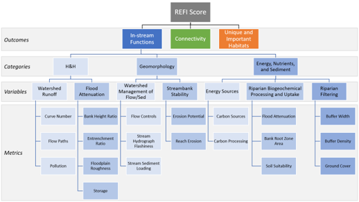

Figure 1. Conceptual model of instream stuff.

# QUANTIFICATION

$REFI_{0} = \frac{instream + habitat + connectivity}{3}$

## Instream Effects of Riparian Zones

$SI_{ins} = 44.706+8.194*ln(w_{avg})$

## Riparian Zones as Corridors

$SI_{cor} = 1.0+10.0*ln(w_{min})$

## Model Code

```r
#Specify function for the simple riparian model (SRM)
  #width.avg = average riparian buffer width for a reach defined in meters
  #width.min = minimum riparian buffer width for a reach defined in meters

SRM <- function(width.avg, width.min){
  #Compute suitability relative to instream outcomes based on contaminant removal mean regression from Ayala et al. (2024)
  SI.ins <- 44.706 + 8.194*log(width.avg)
  SI.ins <- SI.ins / 100

  #Compute suitability relative to habitat outcomes based on biodiversity mean regression from Ayala et al. (2024)
  SI.hab <- 0.667 + 0.044*log(width.avg)
  #SI.hab <- SI.hab / 100
  SI.hab <- SI.hab

  #Compute suitability relative to corridor outcomes based on TBD
  SI.cor <- 1.0 + 10.0*log(width.min)
  SI.cor <- SI.cor / 100

  #Compute overal suitability metric as the average of the three suitability indices
  SI.total <- mean(SI.ins, SI.hab, SI.cor)

  #Send output as data frame
  SRM.out <- data.frame(SI.ins, SI.hab, SI.cor, SI.total)
  colnames(SRM.out) <- c("instream", "habitat", "corridor", "total")
  row.names(SRM.out) <- NULL
  SRM.out
}

#Test function
SRM(50,100)
```

```
##    instream  habitat corridor     total
## 1 0.7676112 0.839129 0.470517 0.7676112
```

Play around with plotting the suitability curves

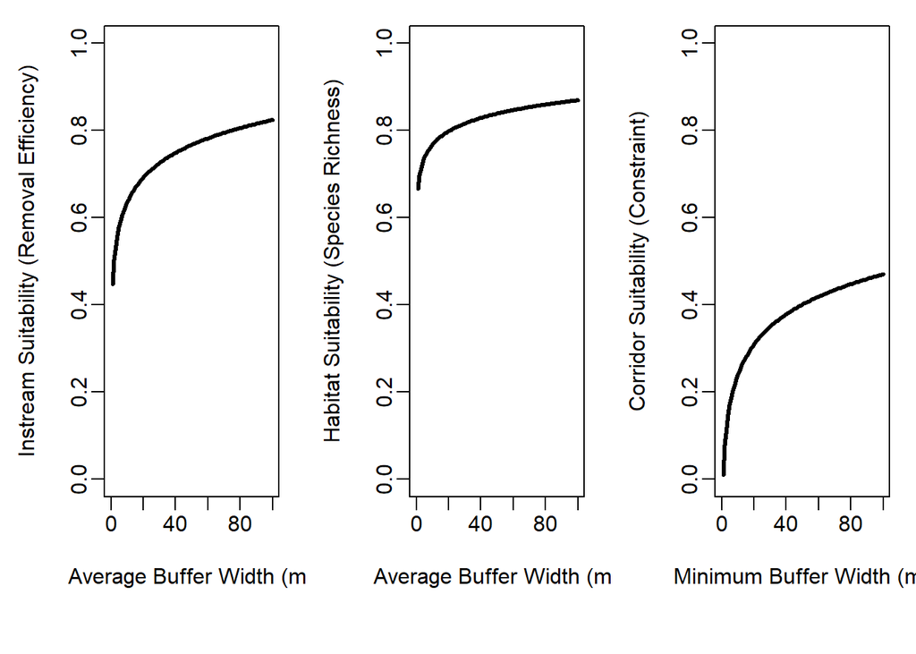

```
##        width.test SIplot.ins SIplot.hab
##   [1,]          0       -Inf       -Inf
##   [2,]          1  0.4470600  0.6670000
##   [3,]          2  0.5038565  0.6974985
##   [4,]          3  0.5370803  0.7153389
##   [5,]          4  0.5606530  0.7279970
##   [6,]          5  0.5789373  0.7378153
##   [7,]          6  0.5938768  0.7458374
##   [8,]          7  0.6065079  0.7526200
##   [9,]          8  0.6174494  0.7584954
##  [10,]          9  0.6271006  0.7636779
##  [11,]         10  0.6357338  0.7683137
##  [12,]         11  0.6435435  0.7725074
##  [13,]         12  0.6506733  0.7763359
##  [14,]         13  0.6572320  0.7798578
```

[output cut: 87 more lines]

```
## [1] 0.7584954
```

```
## [1] 0.5895282
```

## Shiny App

# MODEL EVALUATION

```
##   Component Avg Width (m) Min Width (m) Expected SRM Output
## 1     SIins             0             0        0         NA
## 2     SIins          1000             0        1         NA
## 3     SIhab             0          1000        1         NA
## 4     SIins             0             0        0         NA
## 5     SIins          1000             0        1         NA
## 6     SIhab             0          1000        1         NA
## 7     SIins             0             0        0         NA
## 8     SIins          1000             0        1         NA
## 9     SIhab             0          1000        1         NA
```

# MODEL APPLICATION

# SUMMARY

# ACKNOWLEDGEMENTS

Model development was funded by the U.S. Army Corps of Engineers’ Ecosystem Management and Restoration Research Program ([EMRRP](https://emrrp.el.erdc.dren.mil/)). The authors are grateful to Garrett Menichino, Sam Wiest, and Colton Shaw for their broader contributions to an EMRRP study of riparian ecological modeling and their roles in assisting with the web application. This model was reviewed by Kip Runyon, Mick Porter, Aubrey Harris, and others. Opinions expressed here are those of the authors and not necessarily those of the agencies they represent.

# References

Ayala Torres R., Dietterich L., Wiest S., and McKay S.K. 2024. Meta-analysis of riparian zone width effects on contaminant removal and biodiversity. Submitted to Ecological Applications.

Fischer, R. A., & Fischenich, J. C. (2000). Complexity Value as a Planning Tool Design Recommendations for Riparian Corridors and Vegetated Buffer Strips.

Gurevitch, J., Koricheva, J., Nakagawa, S., & Stewart, G. (2018). Meta-analysis and the science of research synthesis. Nature, 555(7695), 175–182. https://doi.org/10.1038/nature25753

Lind, L., Hasselquist, E. M., & Laudon, H. (2019). Towards ecologically functional riparian zones: A meta-analysis to develop guidelines for protecting ecosystem functions and biodiversity in agricultural landscapes. In Journal of Environmental Management (Vol. 249). Academic Press. https://doi.org/10.1016/j.jenvman.2019.109391

Wenger, S. (1999). A review of the scientific literature on riparian buffer width , extent and vegetation. In Institute of Ecology, University of Georgia. https://www.soils.org/publications/sssaj/abstracts/73/6/2078

Zhang, X., Liu, X., Zhang, M., Dahlgren, R. A., & Eitzel, M. (2010). A Review of Vegetated Buffers and a Meta‐analysis of Their Mitigation Efficacy in Reducing Nonpoint Source Pollution. Journal of Environmental Quality, 39(1), 76–84. https://doi.org/10.2134/jeq2008.0496